# Analysis of Pilot Study Data

R tutorial

Rajesh Sigdel

2020-12-09

- What is the frequency of wood at each site?
- Are frequencies of large wood at each site statistically significant from each other?
- What is the volume of large wood at each site?
- Is the volume of large wood at each site significantly different from each other?
- Is the length of large wood at each site significantly different from each other?
- Is the length of large wood at each site significantly different from each other?

# Importing data

We need to import the dataset first. The dataset can be downloaded from [here](https://drive.google.com/file/d/1JoFpbJSQZwklf41dkDsJufUL0Gd-l6mn/view). (If using windows, press “control” button and [click here](https://drive.google.com/file/d/1JoFpbJSQZwklf41dkDsJufUL0Gd-l6mn/view) it will open in your default browser)

```r
setwd("D:/Pilot_Study/Descriptive-statistics-Mann-Whitney-U-test-and-Chi-squared-test")

library(readxl)

LathamPark <- read_excel("D:/Pilot_Study/Data.xlsx",
                   sheet = "LathamPark")


LakeDanielPark <- read_excel("D:/Pilot_Study/Data.xlsx",
                         sheet = "LakeDanielPark")

Auduban <- read_excel("D:/Pilot_Study/Data.xlsx",
                             sheet = "Auduban")
```

# Installing packages

```r
# install.packages("tidyverse")
library(tidyverse)
# install.packages("devtools")
# devtools::install_github("thomasp85/patchwork")
library(patchwork)
# install.packages("gdata")
library(gdata)
# install.packages("flextable")
library(flextable)
#install.packages("leaflet")
library(leaflet)
```

## Map of the Study site

```r
library(readxl)
data <- read_excel("Data_for_map.xlsx")




m <- leaflet() %>%
  addTiles() %>%
  addMarkers( data = data, lng = ~Long, lat = ~lat,
              popup = ~ Name)
m
```

[interactive chart not shown]

We are now converting all the Null Values into zeros using a function

```r
hybrd.ifelse <- function(x) {
  mutate_all(x, ~ifelse(is.na(.), 0, .))
}
```

Now, applying the function into our dataframe

```r
LathamPark <- hybrd.ifelse(LathamPark)
Auduban <- hybrd.ifelse(Auduban)
LakeDanielPark <- hybrd.ifelse(LakeDanielPark)
```

## The formula to calculate Volume is:

```r
Volume_Calc <- function(dataframe,
                   Zone1, Zone2, Zone3, Zone4, PieceD) {
  length <-  (Zone1 + Zone2 + Zone3+ Zone4)
  diameter_m <- (PieceD/100) # Converting diameter into meter
  radius <- diameter_m/2     # Radius = d/2
  volume <- (length*pi*(radius^2))  # L*pi*r^2
  a <- cbind(dataframe, length, diameter_m, radius, volume)
}
```

Applying the function into our dataframe

```r
LathamPark <- Volume_Calc(LathamPark, LathamPark$Zone1, LathamPark$Zone2,
         LathamPark$Zone3, LathamPark$Zone4, LathamPark$PieceD)



Auduban <- Volume_Calc(Auduban, Auduban$Zone1, Auduban$Zone2,
                         Auduban$Zone3, Auduban$Zone4, Auduban$PieceD)

LakeDanielPark <- Volume_Calc(LakeDanielPark, LakeDanielPark$Zone1,
                                LakeDanielPark$Zone2,
                                LakeDanielPark$Zone3, LakeDanielPark$Zone4,
                                LakeDanielPark$PieceD)
```

Selecting our volume column

```r
Auduban_V <- mutate (Auduban, "Auduban Volume" = volume) %>%
  select("Auduban Volume")
LakeDanielPark_V <- mutate(LakeDanielPark, "Lake Daniel Park volume" = volume) %>%
  select("Lake Daniel Park volume")
LathamPark_V <- mutate(LathamPark, "Latham Park volume" = volume) %>%
  select("Latham Park volume")
```

```r
Volume <- gdata::cbindX(LakeDanielPark_V, Auduban_V,
       LathamPark_V)
```

```r
Volume <- pivot_longer(Volume, c("Lake Daniel Park volume", "Latham Park volume",
                       "Auduban Volume" ), names_to = "Field",
             values_to = "Volume") %>% drop_na()
```

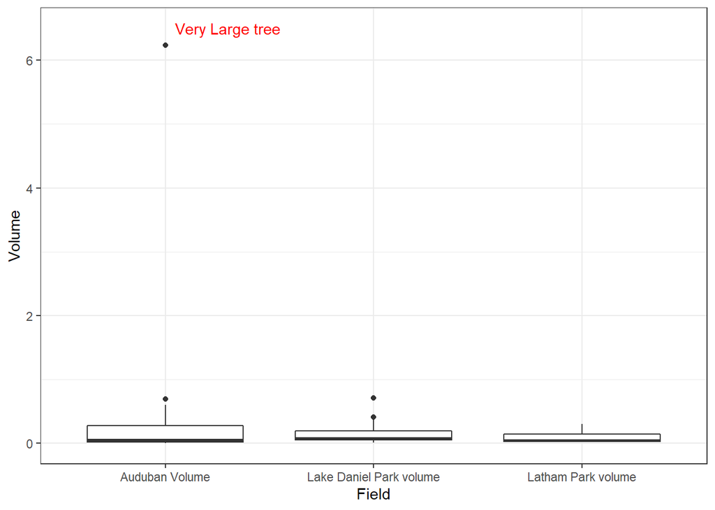

```r
ggplot(Volume, aes(x = Field, y = Volume))+
  geom_boxplot()+
  theme_bw()+
  annotate(geom="text", x=1.3, y=6.5, label="Very Large tree",
           color="red")
```

```r
Volume_hist<- function(dataframe, Site){
  a <- filter(dataframe, Field == Site)
  b <- ggplot(a, aes(x = Volume, fill= Site))+
    geom_histogram()+
    labs (x = Site)+
    theme_bw()+
    theme(legend.position = "none")
}
```

```r
Auduban_V_ggplot <- Volume_hist(Volume, "Auduban Volume")
LathamPark_V_ggplot <- Volume_hist(Volume, "Latham Park volume")
LakeDanielPark_V_ggplot <- Volume_hist(Volume, "Lake Daniel Park volume")
```

```r
All_site_hist <-
  ggplot(Volume, aes(x = Volume, fill = Volume))+
  geom_histogram()+
  labs (x = "All sites")+
  theme_bw()+
  theme(legend.position = "none")
```

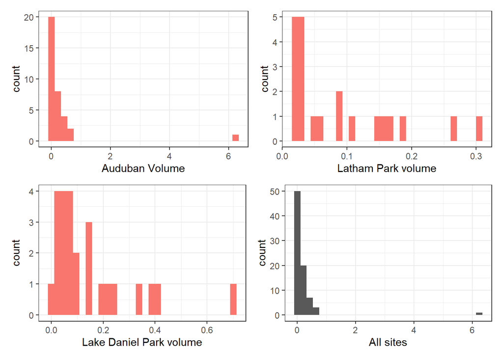

```r
(Auduban_V_ggplot | LathamPark_V_ggplot) /
  (LakeDanielPark_V_ggplot | All_site_hist)
```

The average, median and standard deviation of wood volume in Lake Daniel

```r
mean(LakeDanielPark$volume)
```

```
## [1] 0.1504215
```

```r
sd(LakeDanielPark$volume)
```

```
## [1] 0.163793
```

```r
median(LakeDanielPark$volume)
```

```
## [1] 0.07696902
```

The average, median and standard deviation of wood volume in Audubon

```r
mean(Auduban$volume)
```

```
## [1] 0.3286007
```

```r
sd(Auduban$volume)
```

```
## [1] 1.04468
```

```r
median(Auduban$volume)
```

```
## [1] 0.05677486
```

The average, median and standard deviation of wood volume in Latham Park

```r
mean(LathamPark$volume)
```

```
## [1] 0.08859561
```

```r
sd(LathamPark$volume)
```

```
## [1] 0.08513687
```

```r
median(LathamPark$volume)
```

```
## [1] 0.04846692
```

```r
a <- Volume %>%
  group_by(Field) %>%
  summarise(
    "Volume Per 100 meters"  = (sum(Volume))/2,  # Per 100 meter
    mean = mean(Volume, na.rm = TRUE),
    sd = sd(Volume, na.rm = TRUE),
    median = median(Volume, na.rm = TRUE),
    IQR = IQR(Volume, na.rm = TRUE))
a <- flextable(a)
autofit(a, add_w = 0.001, add_h = 0.1)
```

| Field | Volume Per 100 meters | mean | sd | median | IQR |
| --- | --- | --- | --- | --- | --- |
| Auduban Volume | 5.7505120 | 0.32860068 | 1.04468045 | 0.05677486 | 0.2635415 |
| Lake Daniel Park volume | 1.8802691 | 0.15042153 | 0.16379296 | 0.07696902 | 0.1369954 |
| Latham Park volume | 0.9302539 | 0.08859561 | 0.08513687 | 0.04846692 | 0.1188700 |

Jams are excluded in volume calculation because the Washington Survey Guide did not include diameter and length to be calculated for Jams)

# Kruskal Wallis test

Kruskal Wallis test is a non - parametric test alternative to ANOVA. This methos is useful for testing whether sample originates from the same population. The reasons for the test: • Volume is a continious data unlike total count of wood logs • The dataset is not normal (very skewed data)

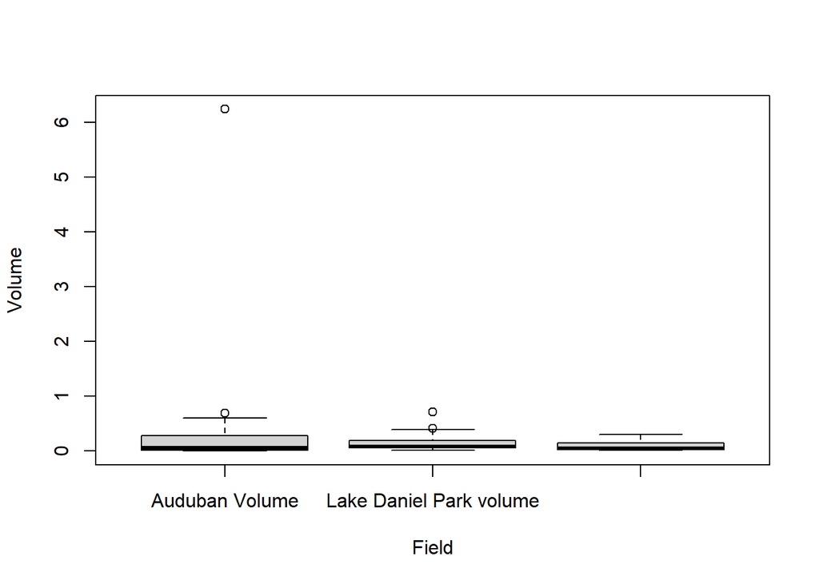

```r
boxplot(Volume~Field, data = Volume)
```

The result of Kurskal Wallis test is:

```r
kruskal.test(Volume ~ Field, data = Volume)
```

```
##
##  Kruskal-Wallis rank sum test
##
## data:  Volume by Field
## Kruskal-Wallis chi-squared = 1.4147, df = 2, p-value = 0.493
```

There is no statistically significant between volume of individual pieces of Lake Daniel, Lake Latham Park and Auduban Preserve.

# Frequency of Large wood per 100 meters

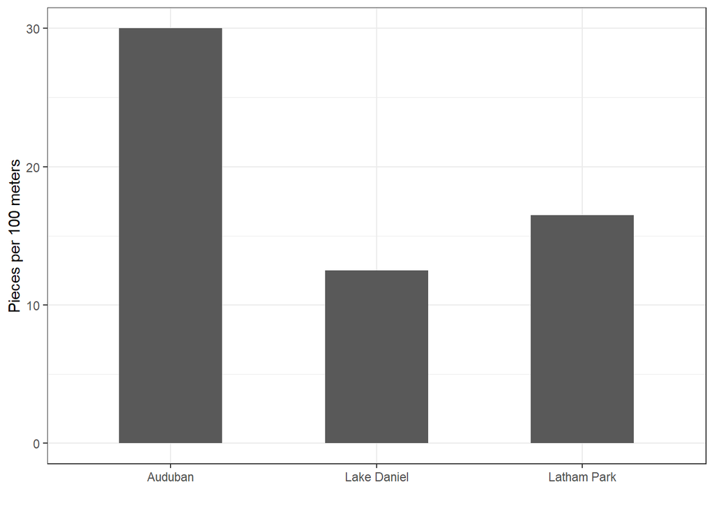

```r
Field <- c("Latham Park", "Lake Daniel" , "Auduban")

Values <- c(33, 25, 60)

Pieces <- data.frame(Field, Values)

Pieces$Per100 <- Values/2

ggplot(data = Pieces, aes(x = Field, y = Per100))+
  geom_col(width = 0.5)+
  theme_bw()+
  ylab("Pieces per 100 meters")+
  xlab("")
```

Ho: p1 = p2= p3 Ha: At least one of the site is different from other

```r
data <- Pieces$Per100
chisq.test(data)
```

```
##
##  Chi-squared test for given probabilities
##
## data:  data
## X-squared = 8.5508, df = 2, p-value = 0.01391
```

The difference in the frequency of Large Wood is statistically significant

# Channel Orientation

```r
CountLP <- LathamPark %>% group_by(`Channel Orient`) %>% count(name = "LathamPark")
CountAu <- Auduban %>% group_by(`Channel Orient`) %>% count(name = "Auduban")
CountLD <- LakeDanielPark %>% group_by(`Channel Orient`) %>% count(name = "LakeDanielPark")





a <- CountLP %>% right_join(CountAu) %>% right_join(CountLD)
flextable::flextable(a)
```

| Channel Orient | LathamPark | Auduban | LakeDanielPark |
| --- | --- | --- | --- |
| A | 8 | 11 | 11 |
| B | 7 | 7 | 4 |
| C | 6 | 14 | 9 |
| D | NA | 3 | 1 |

# Degradation Class

```r
mean(Auduban$`Piece Decay`)
```

```
## [1] 2.028571
```

```r
sd(Auduban$`Piece Decay`)
```

```
## [1] 0.8570028
```

```r
mean(LathamPark$`Piece Decay`)
```

```
## [1] 2.142857
```

```r
sd(LathamPark$`Piece Decay`)
```

```
## [1] 0.853564
```

```r
mean(LakeDanielPark$`Piece Decay`)
```

```
## [1] 2.08
```

```r
sd(LakeDanielPark$`Piece Decay`)
```

```
## [1] 0.8124038
```

# Jams

```r
Sites <- c("Auduban Preserve", "Latham Park", "Lake Daniel Park")
`No. of Jams` <- c(2, 1, 0)

data.frame(Sites, `No. of Jams`)
```

```
##              Sites No..of.Jams
## 1 Auduban Preserve           2
## 2      Latham Park           1
## 3 Lake Daniel Park           0
```

To find the actual length, we need to add all four zones together. The four zones are: zone 1, zone 2, zone 3, and zone 4. We can use a function to perform the task

```r
library(readxl)

LathamPark <- read_excel("D:/Pilot_Study/Data.xlsx",
                   sheet = "LathamPark")


LakeDanielPark <- read_excel("D:/Pilot_Study/Data.xlsx",
                         sheet = "LakeDanielPark")

Auduban <- read_excel("D:/Pilot_Study/Data.xlsx",
                             sheet = "Auduban")

LathamPark <- hybrd.ifelse(LathamPark)
Auduban <- hybrd.ifelse(Auduban)
LakeDanielPark <- hybrd.ifelse(LakeDanielPark)


LathamPark <- Volume_Calc(LathamPark, LathamPark$Zone1, LathamPark$Zone2,
         LathamPark$Zone3, LathamPark$Zone4, LathamPark$PieceD)



Auduban <- Volume_Calc(Auduban, Auduban$Zone1, Auduban$Zone2,
                         Auduban$Zone3, Auduban$Zone4, Auduban$PieceD)

LakeDanielPark <- Volume_Calc(LakeDanielPark, LakeDanielPark$Zone1,
                                LakeDanielPark$Zone2,
                                LakeDanielPark$Zone3, LakeDanielPark$Zone4,
                                LakeDanielPark$PieceD)
```

Selecting our Length column

```r
Auduban_Length <- mutate (Auduban, "Auduban length" = length) %>%
  select("Auduban length")
LakeDanielPark_Lenght <- mutate(LakeDanielPark, "Lake Daniel Park length" = length) %>%
  select("Lake Daniel Park length")
LathamPark_Length <- mutate(LathamPark, "Latham Park length" = length) %>%
  select("Latham Park length")
```

```r
Length <- gdata::cbindX(Auduban_Length, LakeDanielPark_Lenght,
       LathamPark_Length)
```

```r
Length <- pivot_longer(Length, c("Lake Daniel Park length", "Latham Park length",
                       "Auduban length" ), names_to = "Field",
             values_to = "length") %>% drop_na()
```

# Perforning Kruskal Wallis Test on Length

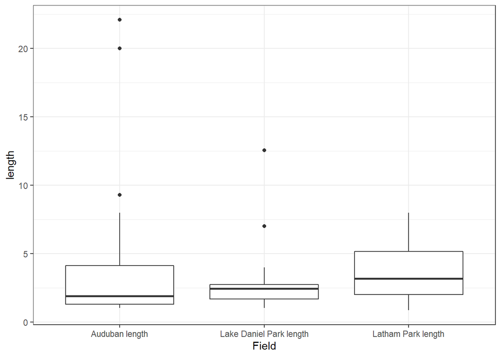

```r
ggplot(data = Length, aes(Field, y = length))+
  geom_boxplot()+
  theme_bw()
```

```r
kruskal.test(length ~ Field, data = Length)
```

```
##
##  Kruskal-Wallis rank sum test
##
## data:  length by Field
## Kruskal-Wallis chi-squared = 5.2773, df = 2, p-value = 0.07146
```

# Performing Kurskal Wallis Test on Diameter

```r
Auduban_Diameter <- Auduban %>%
  select(diameter_m) %>%
  rename(diameter_Audobon = diameter_m)

LakeDanielPark_Diameter <- LakeDanielPark %>%
  select(diameter_m) %>%
  rename(diameter_LakeDanielPark = diameter_m)


LathamPark_Diameter <- LathamPark %>%
  select(diameter_m) %>%
  rename(diamater_LathamPark = diameter_m)
```

```r
Diameter <- gdata::cbindX(Auduban_Diameter, LakeDanielPark_Diameter,
       LathamPark_Diameter)
```

```r
Diameter <- pivot_longer(Diameter, c("diameter_Audobon", "diameter_LakeDanielPark",
                       "diamater_LathamPark" ), names_to = "Field",
             values_to = "diameter") %>% drop_na()
```

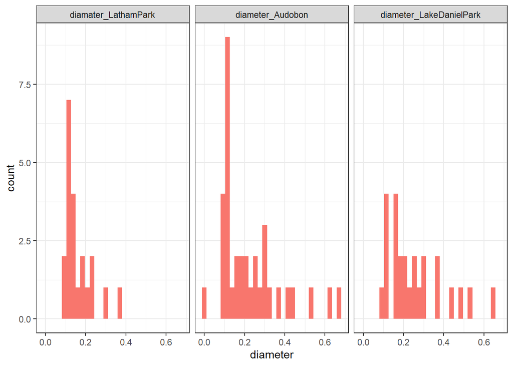

```r
ggplot(data = Diameter, aes(x = diameter, fill = "red"))+
  geom_histogram()+
  theme_bw()+
  theme(legend.position = "none")+
  facet_wrap(~Field)
```

```r
kruskal.test(diameter ~ Field, data = Diameter)
```

```
##
##  Kruskal-Wallis rank sum test
##
## data:  diameter by Field
## Kruskal-Wallis chi-squared = 5.3667, df = 2, p-value = 0.06833
```

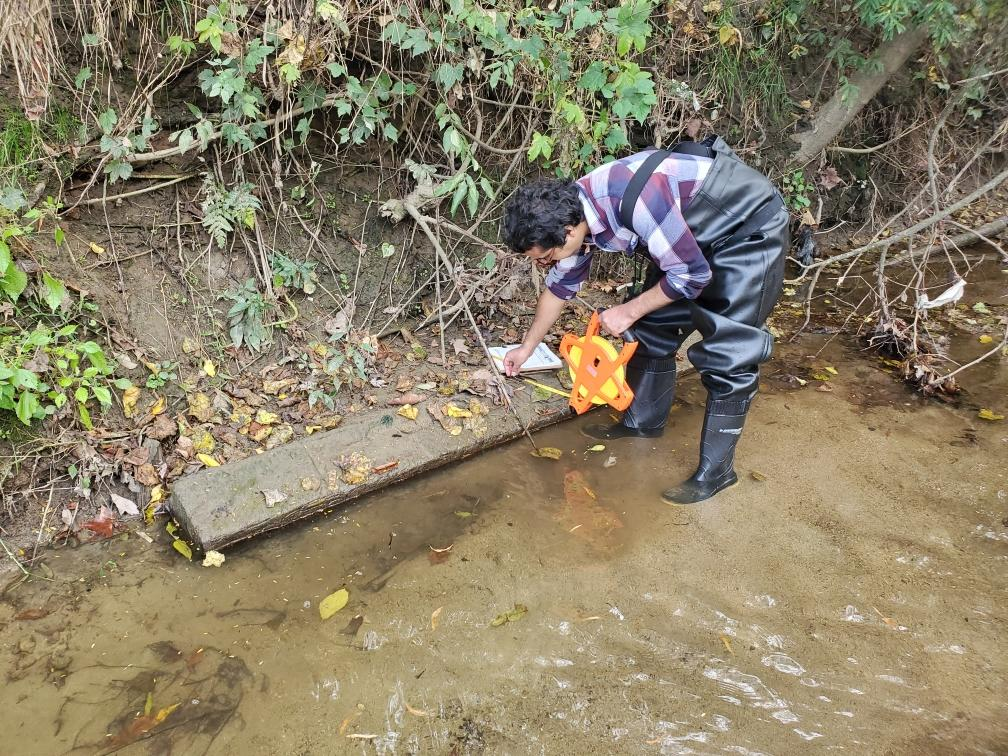

Raj collecting dead large wood data

Feel free to contact me if you have any questions

Thanks